# tidyverse_flows

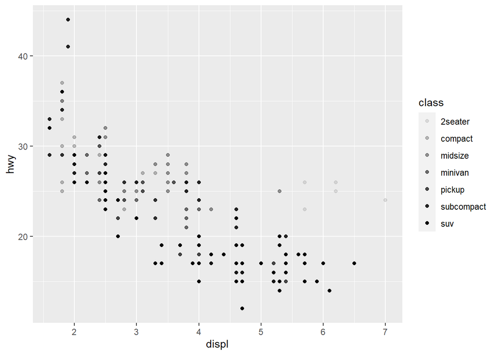

```r
#   alpha =
ggplot(mpg) +
  geom_point(aes(displ, hwy, alpha = class))
```

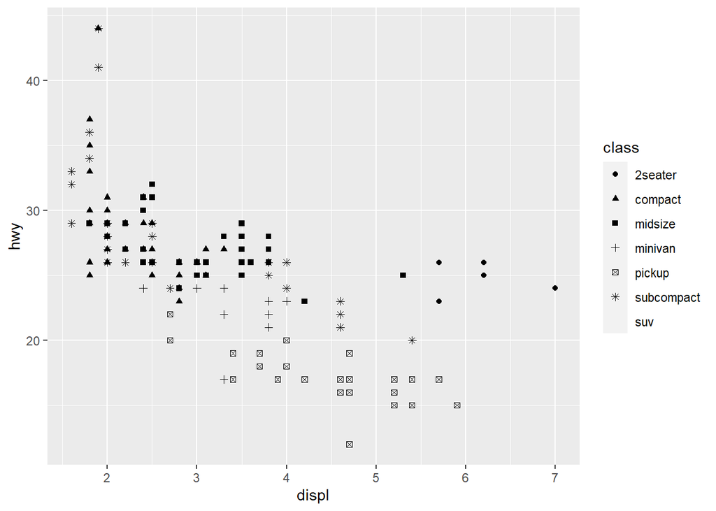

```r
#   shape =
ggplot(mpg) +
  geom_point(aes(displ, hwy, shape = class))
```

We can also just define the aesthetics outside of the mapping argument.

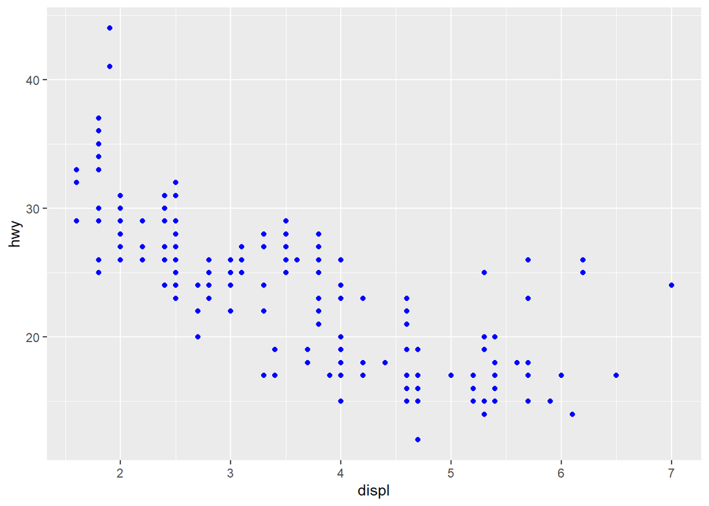

```r
ggplot(mpg) +
  geom_point(mapping = aes(displ, hwy), color = "blue")
```

Size can be specified in mm.

To facet within one dataset, use the facet_wrap() function

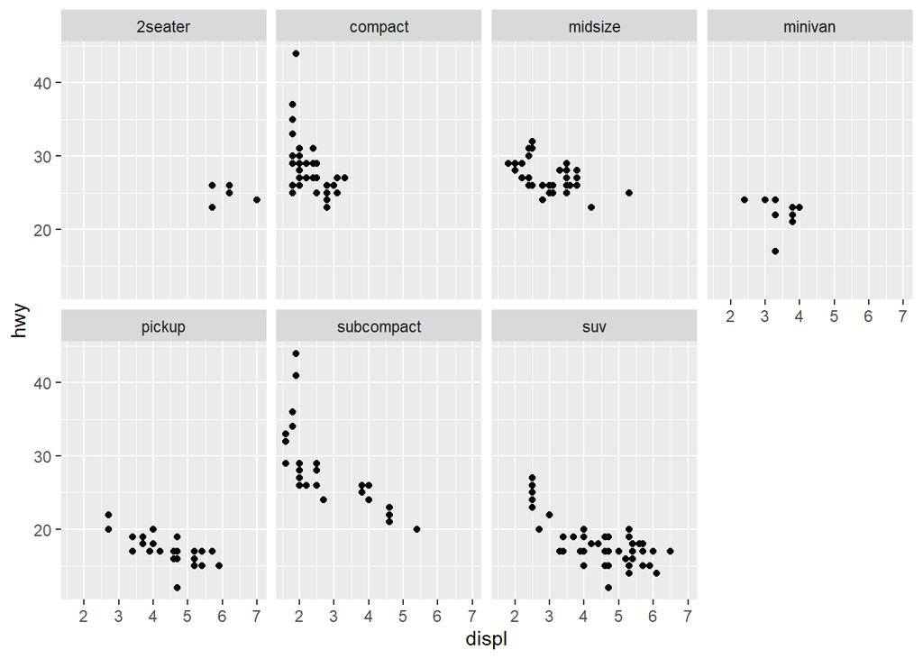

```r
ggplot(mpg) +
  geom_point(aes(displ, hwy)) +
  facet_wrap(~ class, nrow = 2)
```

The facet_grid() function is another way to facet on two-variable axes.

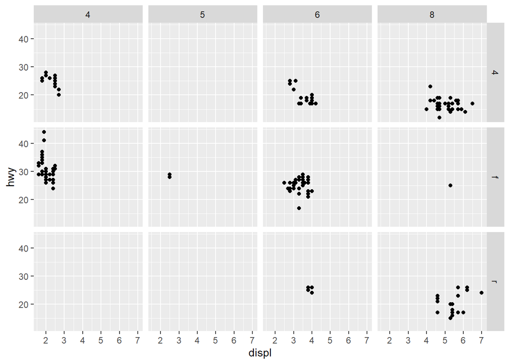

```r
ggplot(mpg) +
  geom_point(aes(displ, hwy)) +
  facet_grid(drv ~ cyl)
```

If you only want to display rows or columns, using “.” as an argument for facet grid will ensure that there is only one dimension.

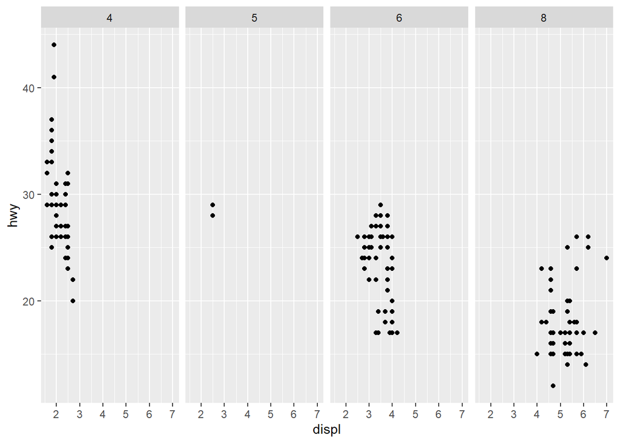

```r
ggplot(mpg) +
  geom_point(aes(displ, hwy)) +
  facet_grid(. ~ cyl)
```

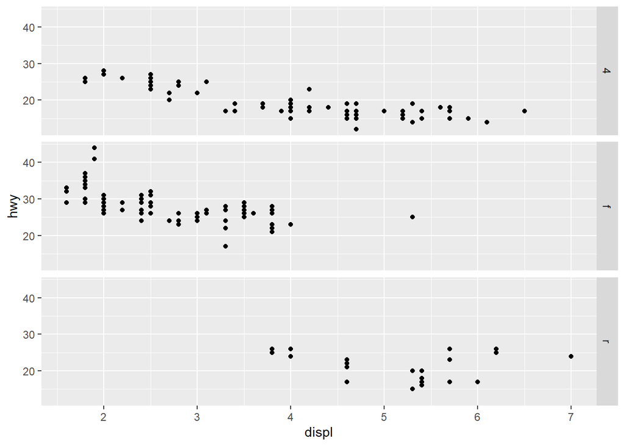

```r
ggplot(mpg) +
  geom_point(aes(displ, hwy)) +
  facet_grid(drv ~ .)
```

Now for a few examples of different geoms

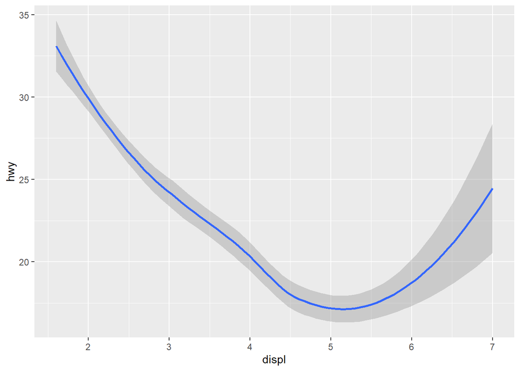

```r
ggplot(mpg) +
  geom_smooth(aes(displ, hwy))
```

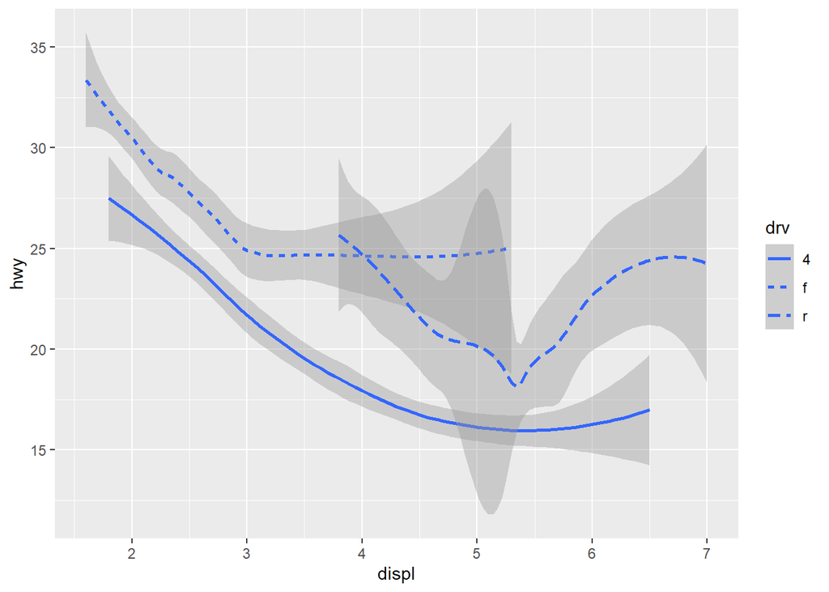

```r
ggplot(mpg) +
  geom_smooth(aes(displ, hwy, linetype = drv))
```

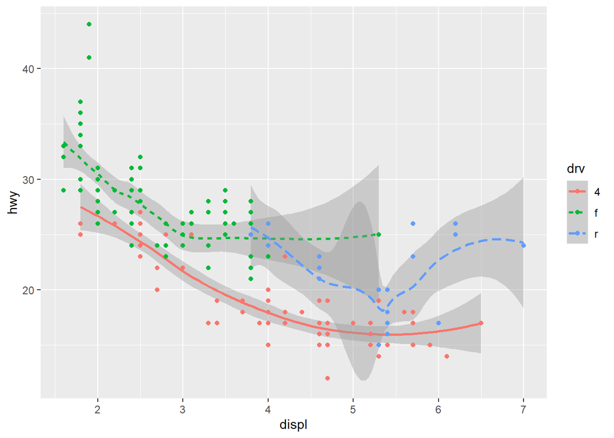

```r
ggplot(mpg, aes(displ, hwy)) +
  geom_smooth(aes(linetype = drv, color = drv)) +
  geom_point(aes(color = drv))
```

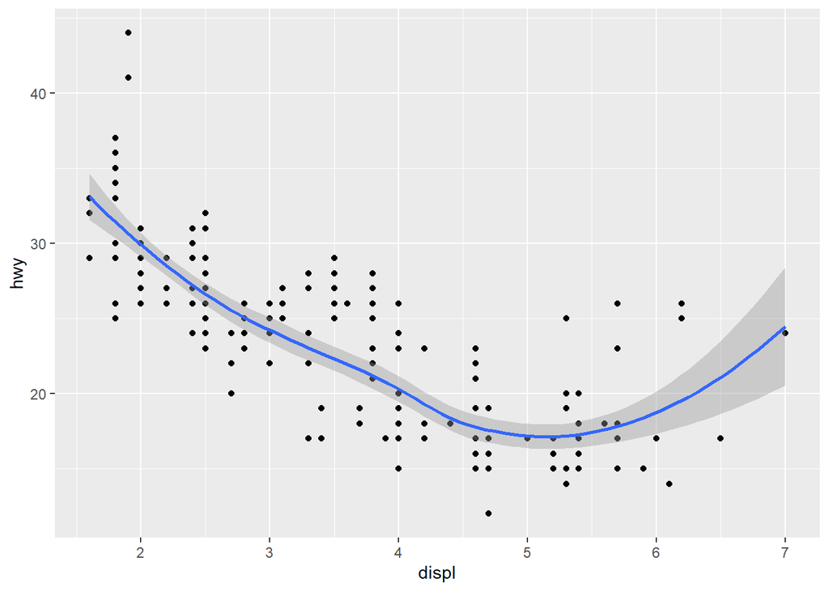

```r
ggplot(mpg, aes(x = displ, y = hwy)) +
  geom_point() +
  geom_smooth()
```

Mixed mapping aesthetics:

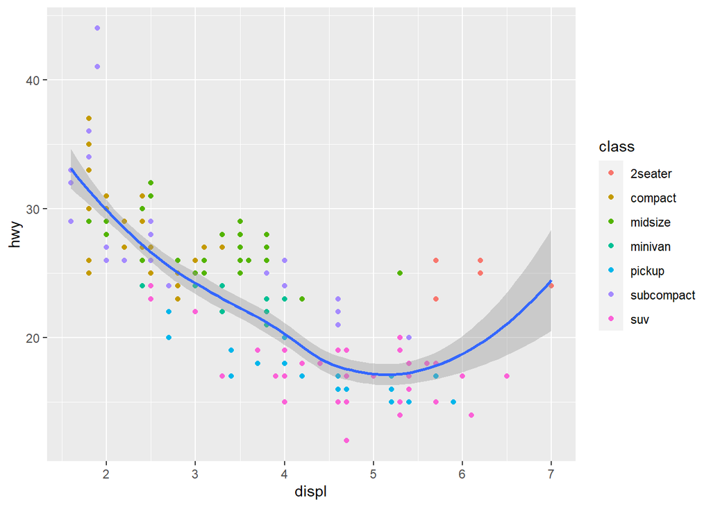

```r
ggplot(mpg, aes(displ, hwy)) +
  geom_point(aes(color = class)) +
  geom_smooth()
```

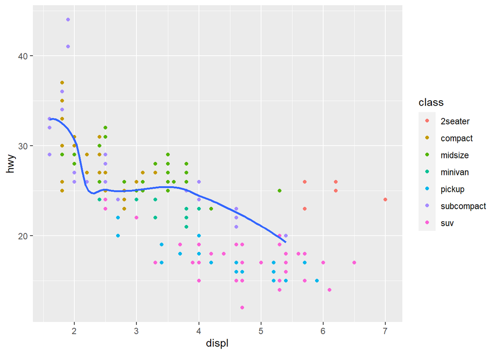

```r
ggplot(mpg, aes(displ, hwy)) +
  geom_point(aes(color = class)) +
  geom_smooth(data = filter(mpg, class == "subcompact"), se = FALSE)
```

Stat Transformations

geom_bar uses a count transformation

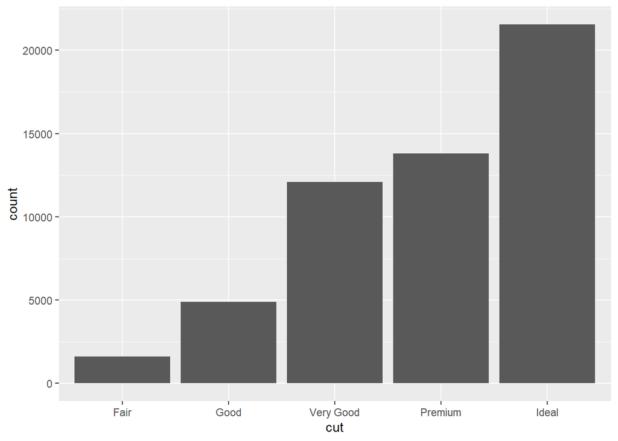

```r
ggplot(diamonds) +
  geom_bar(aes(cut))
```

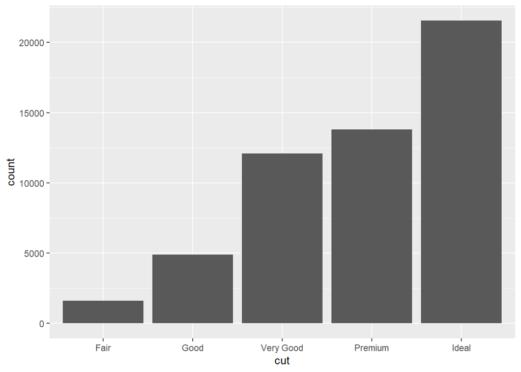

```r
# Same as:
ggplot(diamonds) +
  stat_count(aes(cut))
```

You can change the stat of certain type of plot:

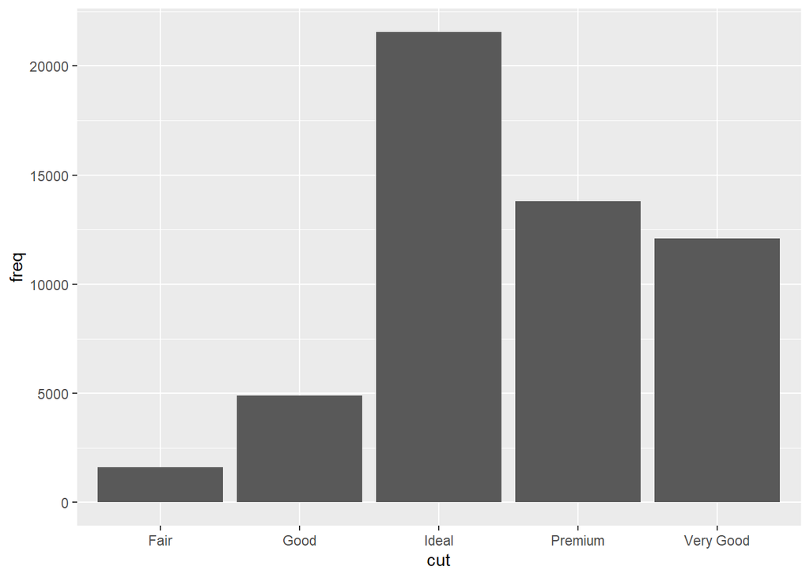

```r
demo <- tribble(
  ~cut,         ~freq,
  "Fair",       1610,
  "Good",       4906,
  "Very Good",  12082,
  "Premium",    13791,
  "Ideal",      21551
)

ggplot(demo) +
  geom_bar(aes(cut, freq), stat = "identity")
```

You can also do things like display the proportion instead of the count:

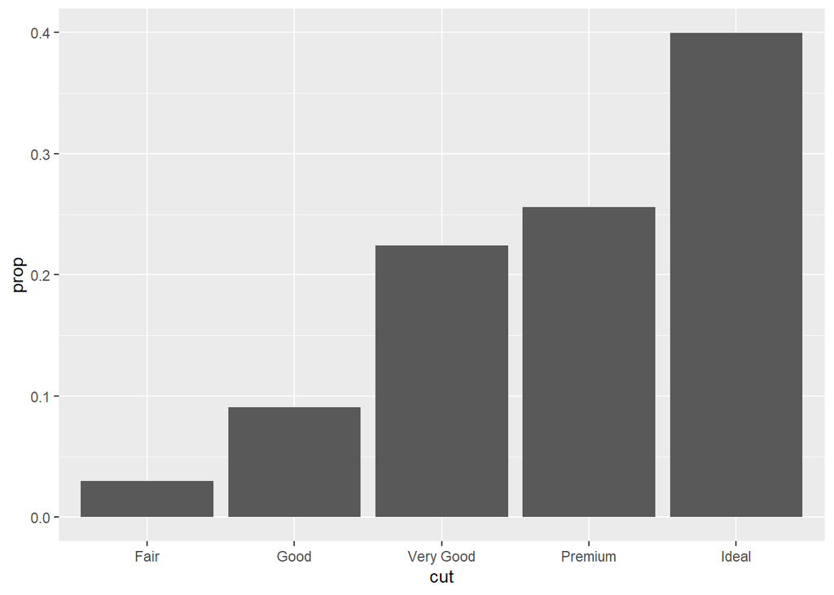

```r
ggplot(diamonds) +
  geom_bar(aes(cut, stat(prop), group = 1))
```

Or you can highlight different values within the data set with a summary plot:

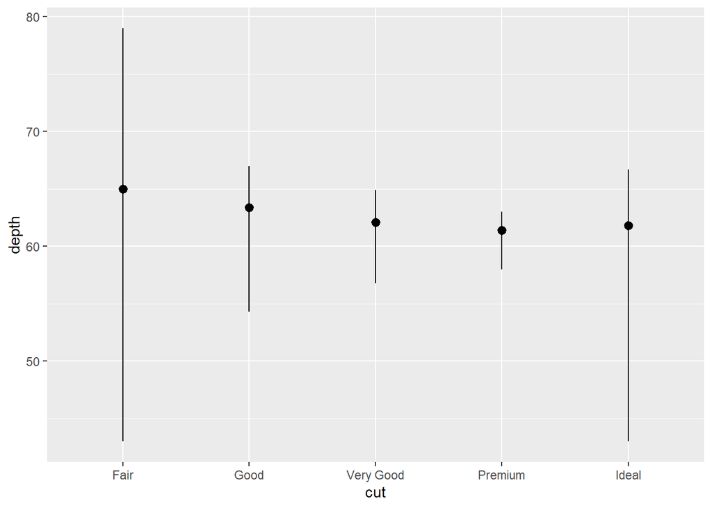

```r
ggplot(diamonds) +
  stat_summary(aes(x = cut, y = depth),
    fun.min = min,
    fun.max = max,
    fun = median
  )
```

Bar chart adjustments:

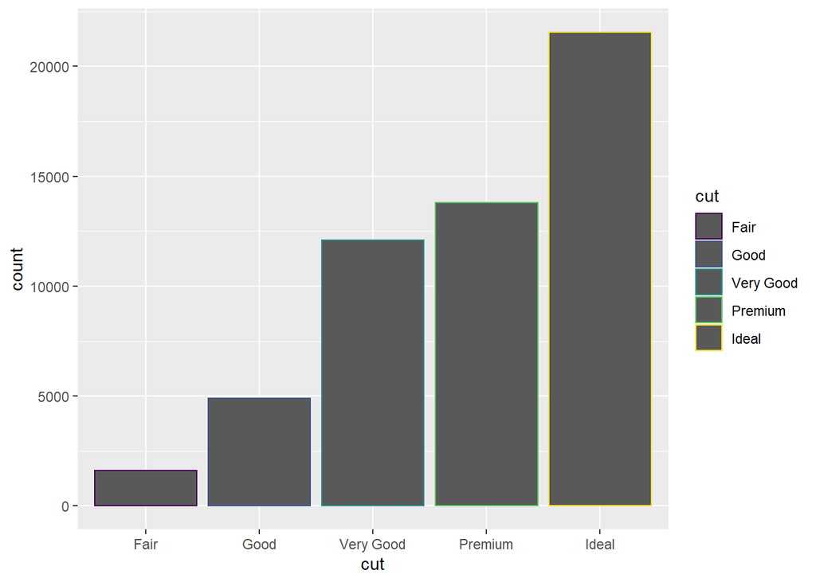

```r
ggplot(diamonds) +
  geom_bar(aes(cut, color = cut))
```

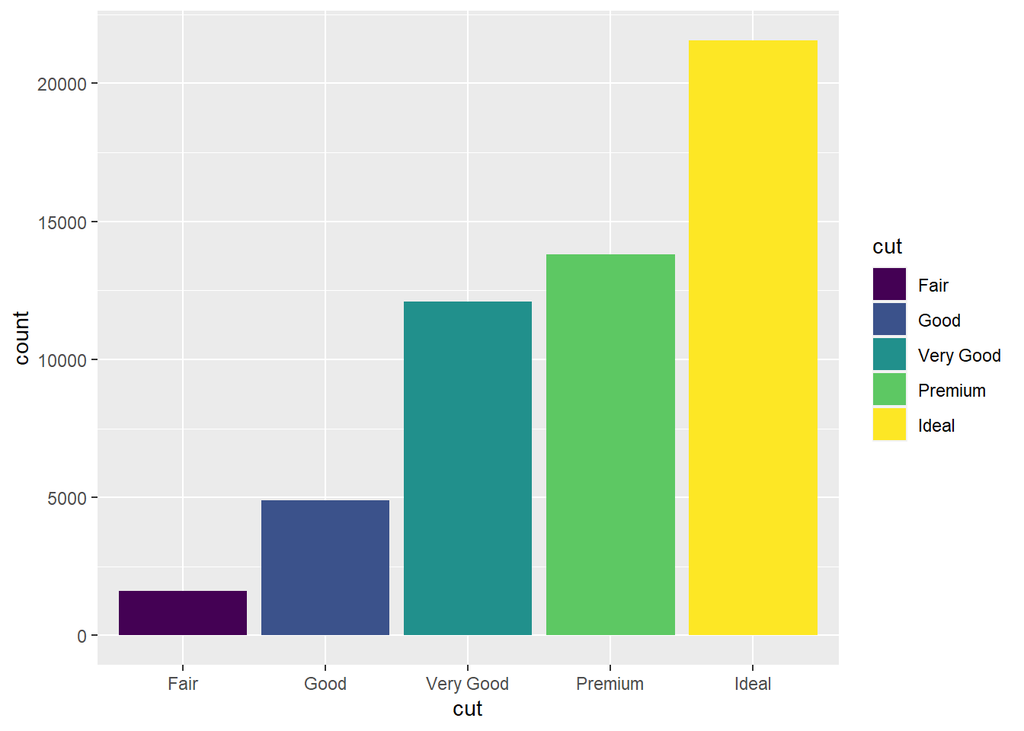

```r
ggplot(diamonds) +
  geom_bar(aes(cut, fill = cut))
```

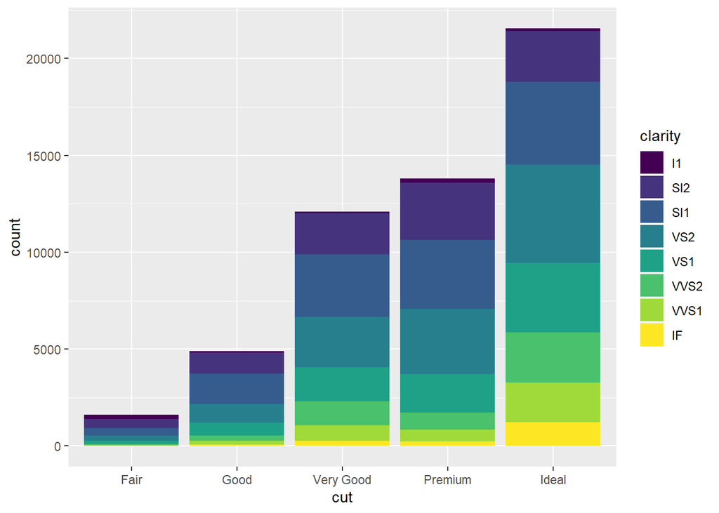

```r
ggplot(diamonds) +
  geom_bar(aes(cut, fill = clarity))
```

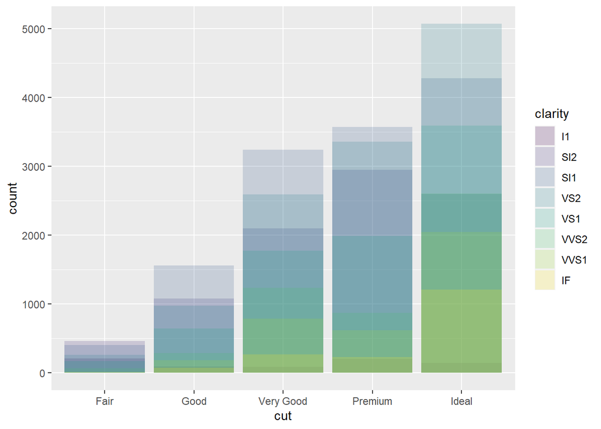

```r
ggplot(diamonds, aes(cut, fill = clarity)) +
  geom_bar(alpha = 1/5, position = "identity")
```

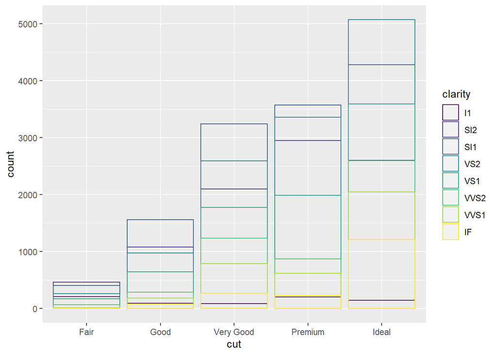

```r
ggplot(diamonds, aes(cut, color = clarity)) +
  geom_bar(fill = NA, position = "identity")
```